# ST_2195 coursework part 2

Darren See

## load librarys

Here we check if packages ‘tidyverse’ and ‘data.table’ are already installed and if not we install the packages and load the packages ‘tidyverse’ , ‘data.table’ and ‘ggplot2’

```r
if (!"tidyverse" %in% rownames(installed.packages())) {
  install.packages("tidyverse")
}
if (!"data.table" %in% rownames(installed.packages())) {
  install.packages("data.table")
}
library(tidyverse)
library(data.table)
```

```r
library(ggplot2)
```

Here we use data.table package fread function to read csv files 1998.csv to 2007.csv quickly, looking at the data we have a dataframe with 63188334 observations and 29 variables

```r
combined_plane <-
  list.files(pattern = "(199[8-9]|200[0-7])\\.csv$") %>%
  map_df(~fread(.)) #read csvs and combine them into a single dataframe
```

## Subsetting dataframe

```r
combined_plane<- combined_plane[!is.na(combined_plane$ActualElapsedTime),c('Year','Month','DayofMonth','DayOfWeek','DepTime','CRSDepTime','CRSArrTime','ArrDelay','DepDelay','Cancelled','Diverted','TailNum','Distance')] #check for NAs in ActualElapsedTime column and include only selected column into the dataframe
combined_plane<- subset(combined_plane,DepTime <=2359) #remove invalid rows of Dep>2359
```

We then subset the dataframe into two separate dataframes one for delayed flights(delayed_df) with parameters of Arrival delay or departure delay >0, and one for on time flights(ontime_df) with parameters of Arrival delay and Departure delay less than or equals to 0. Looking at the data, we have delayed_df with 32943880 observations and ontime_df with 28671623 observations, their total observations adding up to that of combined_plane.

```r
delayed_df <- subset(combined_plane, (ArrDelay > 0 | DepDelay > 0))
ontime_df <- subset(combined_plane, (ArrDelay <= 0 & DepDelay <= 0))
```

## Data visualisation(plotting histogramns of ontime and delayed dataframe)

Here we use a for loop for years 1998 to 2007 to plot a histogram of the count of on time flights and delayed flights making use of the delayed_df and ontime_df we subset above, for every loop it would filter entries of that specific year and would plot frequency as the y-axis and we use DayofWeek column as the x-axis

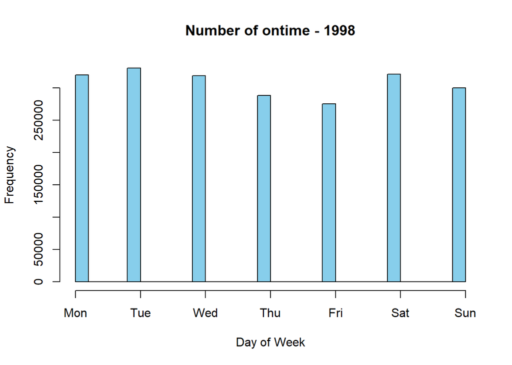

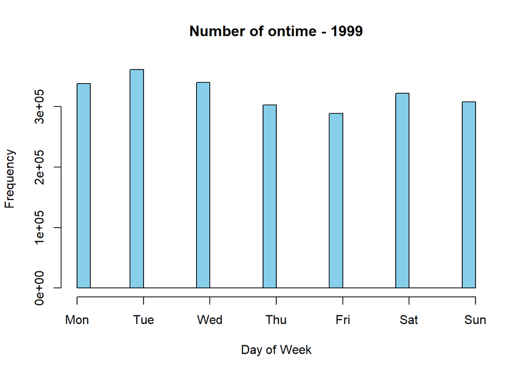

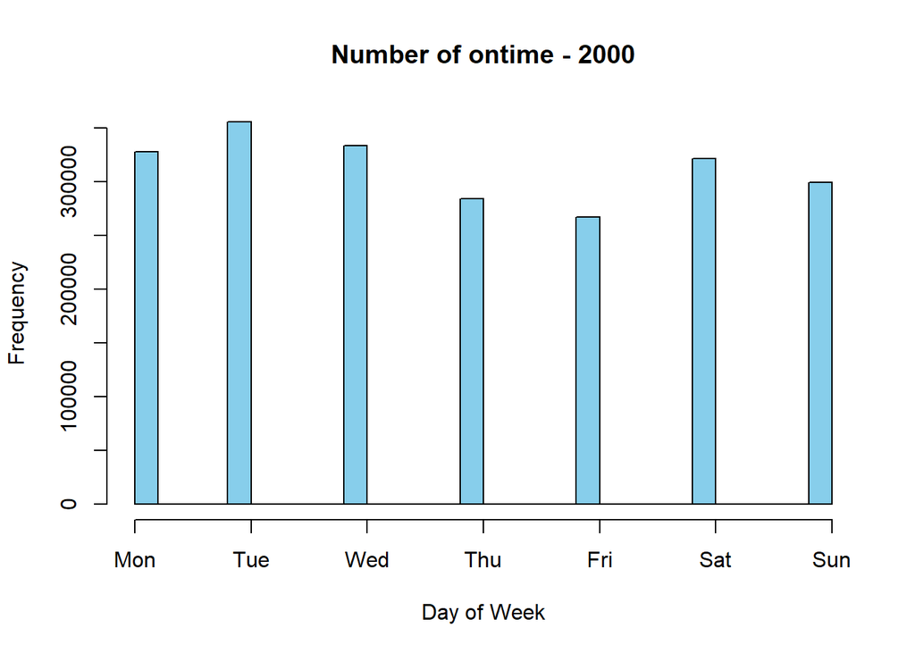

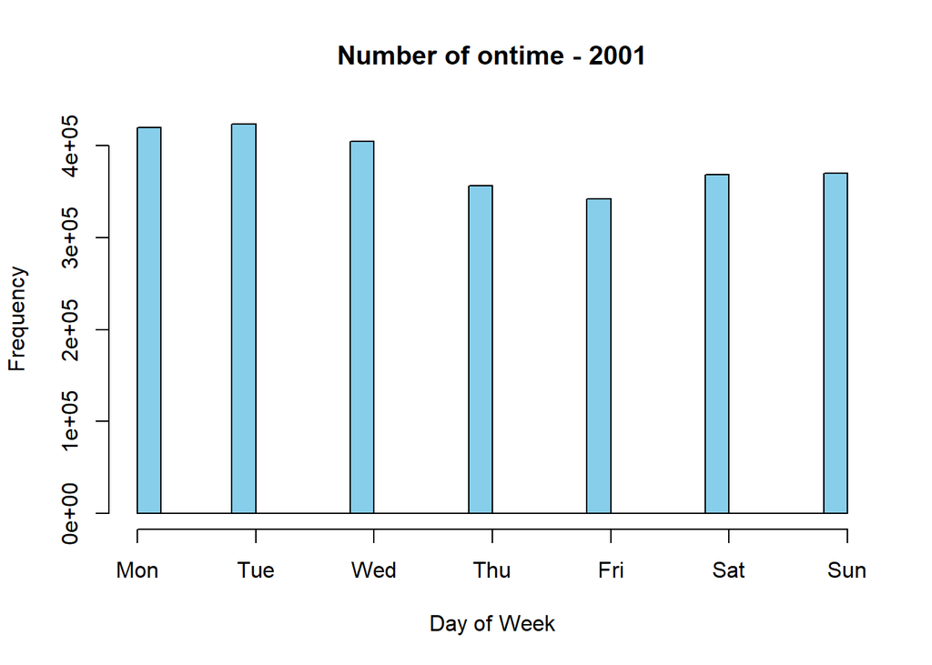

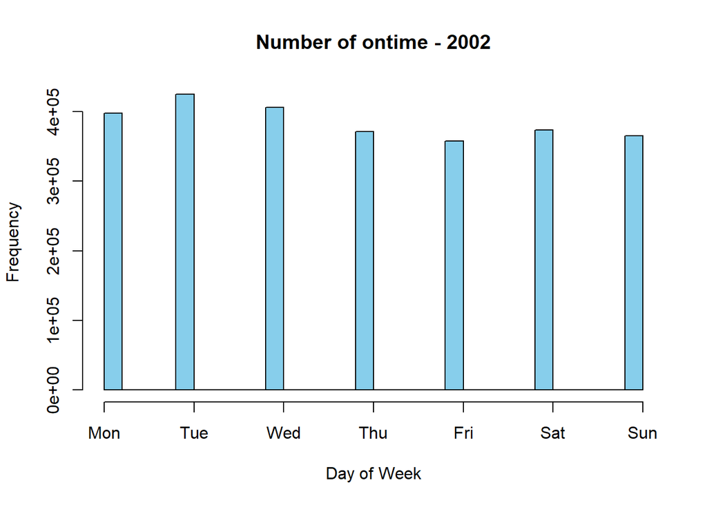

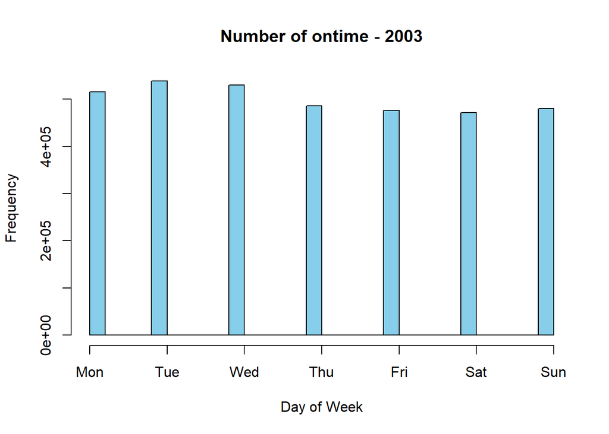

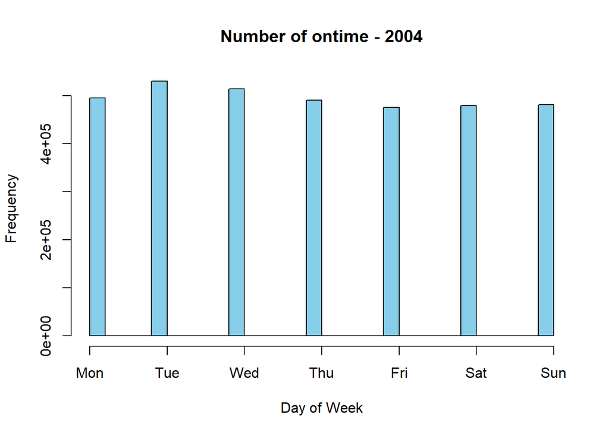

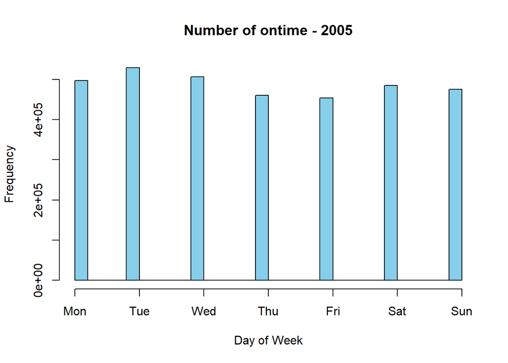

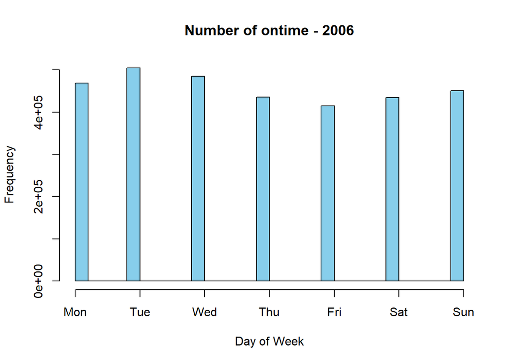

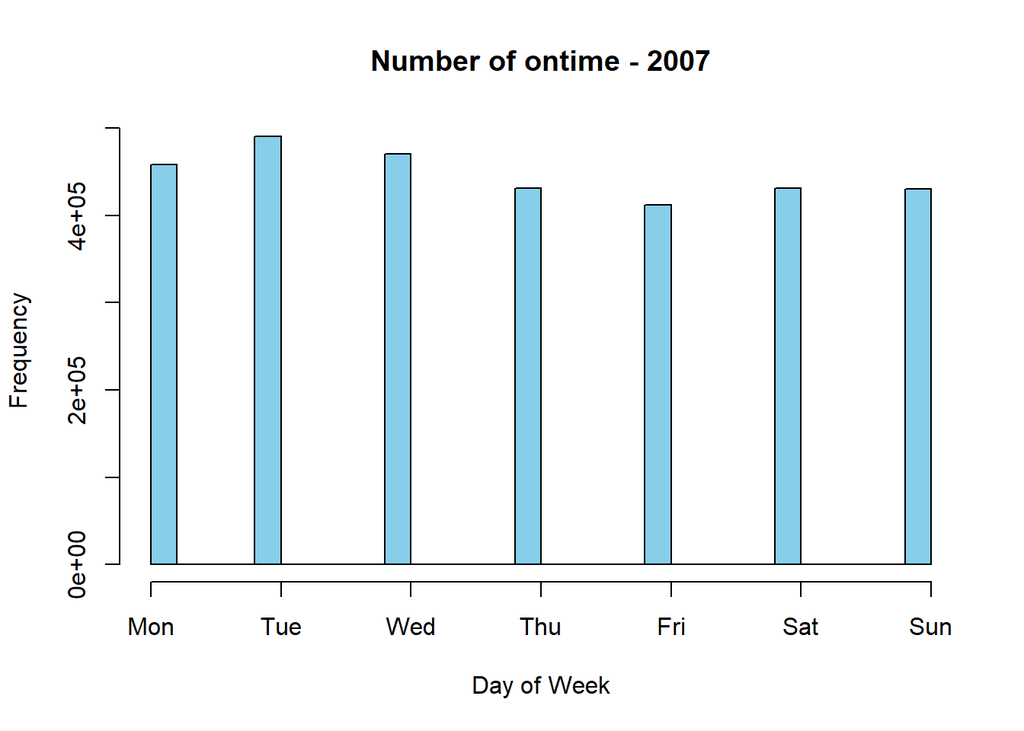

```r
for(year in 1998:2007){
hist(x = ontime_df$DayOfWeek[ontime_df$Year == year], xlab = "Day of Week", main = paste("Number of ontime -", year),xaxt = "n",col = "skyblue")
axis(side = 1, at = 1:7, labels = c("Mon", "Tue", "Wed", "Thu", "Fri", "Sat", "Sun"))}
```

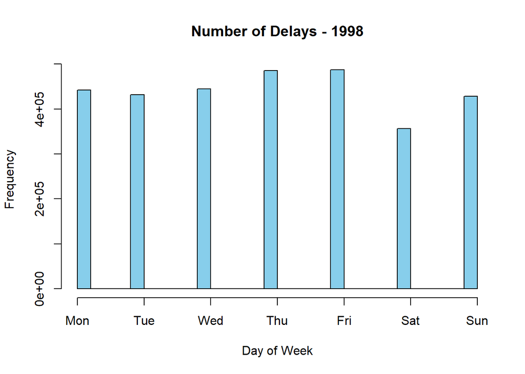

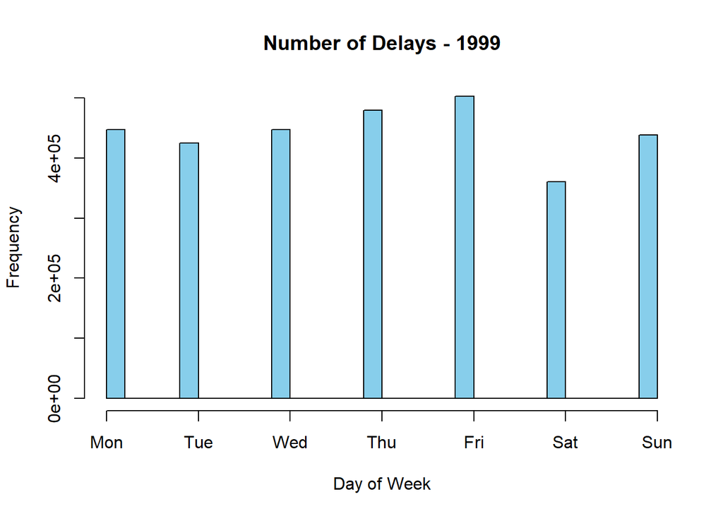

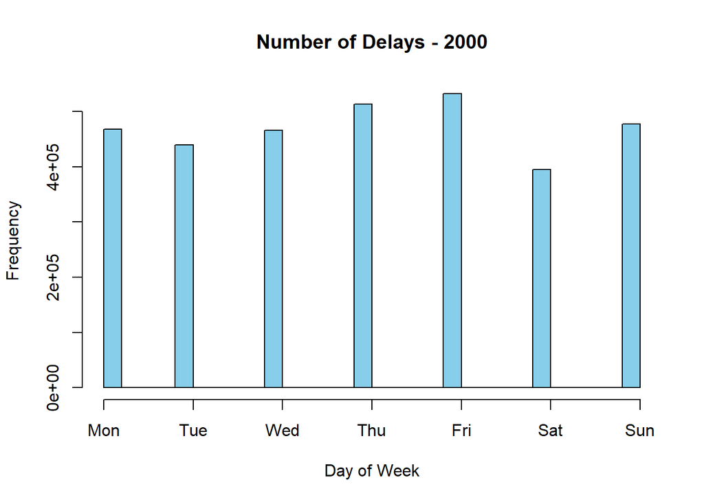

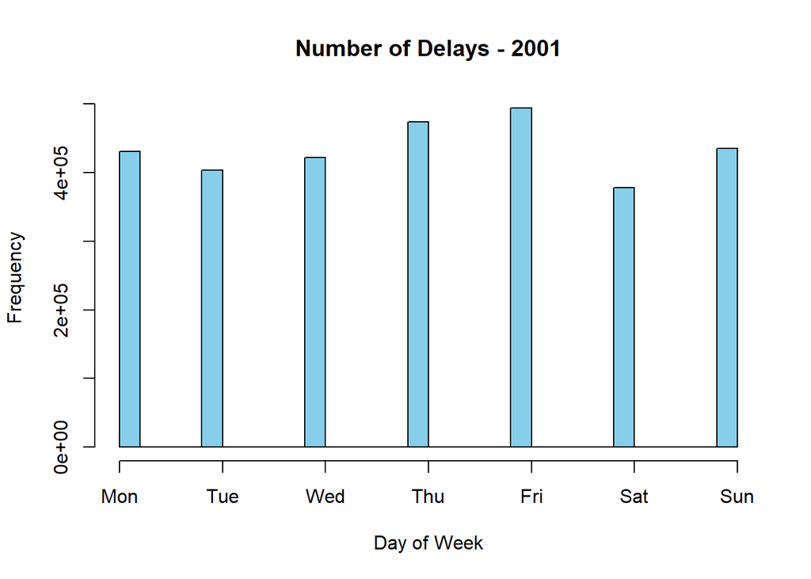

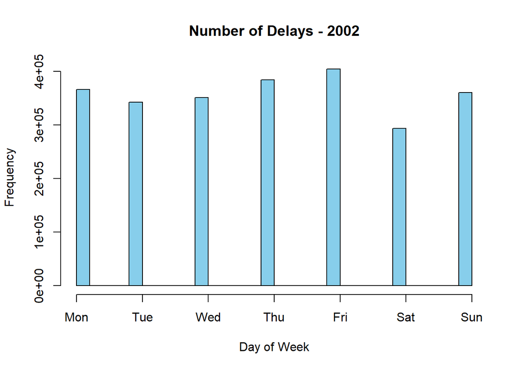

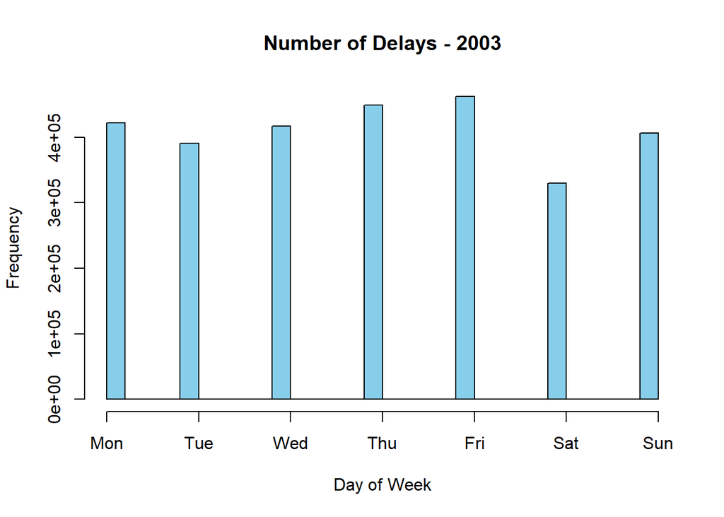

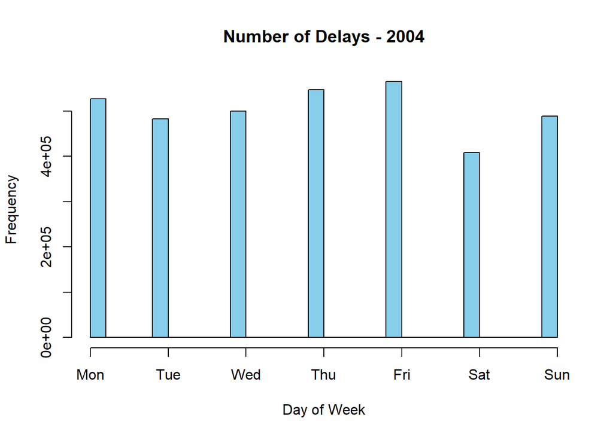

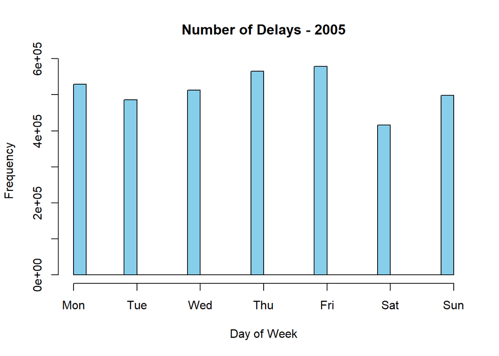

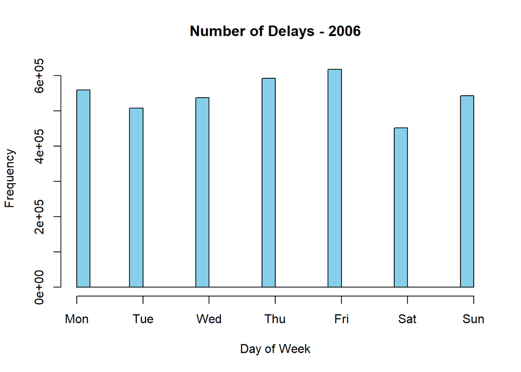

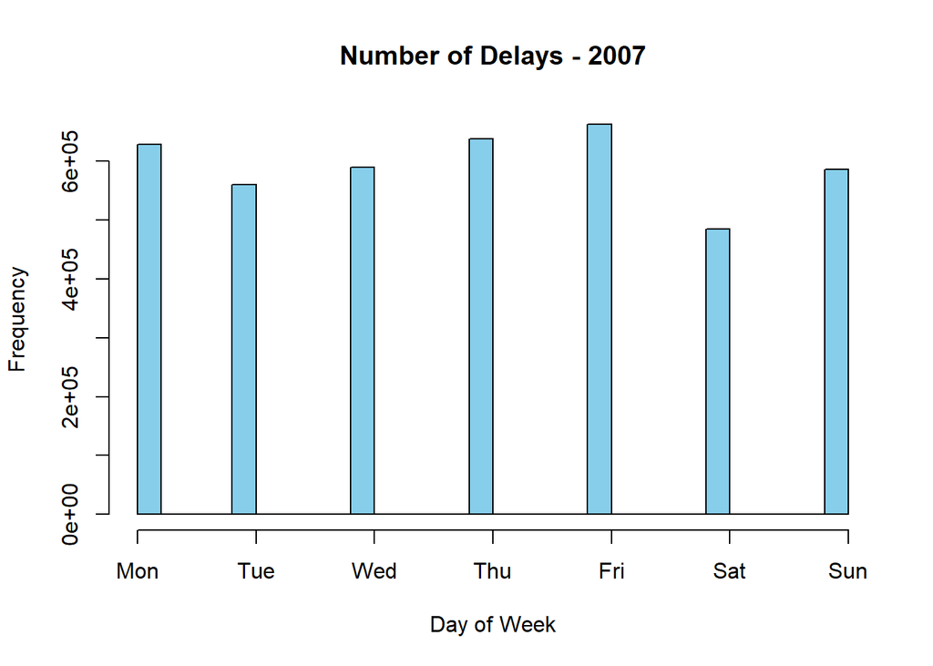

```r
for(year in 1998:2007){
hist(x = delayed_df$DayOfWeek[delayed_df$Year == year], xlab = "Day of Week", main = paste("Number of Delays -",year),xaxt = "n",col = "skyblue")
axis(side = 1, at = 1:7, labels = c("Mon", "Tue", "Wed", "Thu", "Fri", "Sat", "Sun"))}
```

Looking at the bar graphs across the different years for on time flights we can see that Tuesday consistently have the most number of on time flights across the years while looking at the different years on delayed flights, we can see that Saturday consistently has the least number of delayed flights, while still having a good number of on time flights across the year. Hence we can come to a conclusion that Tuesday is the best weekday to fly to advoid delays and Saturday is the best weekend to fly to avoid delays.

## Hourly Analysis

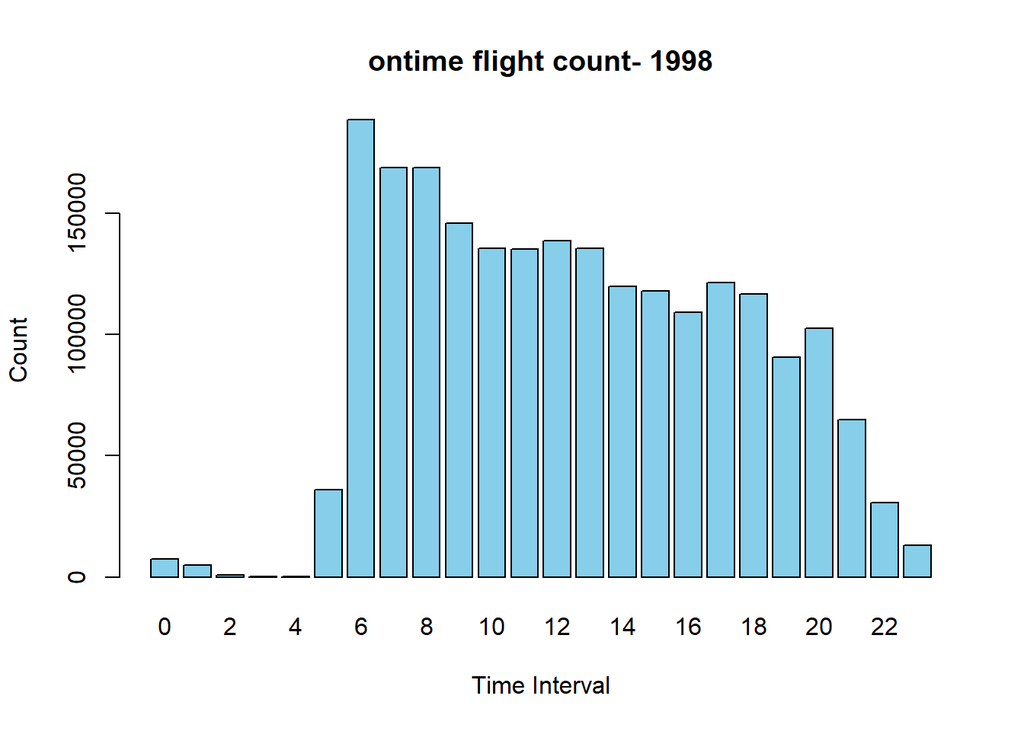

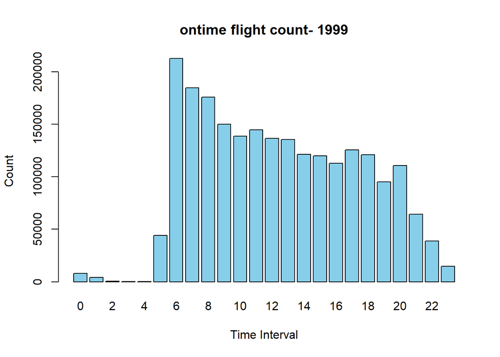

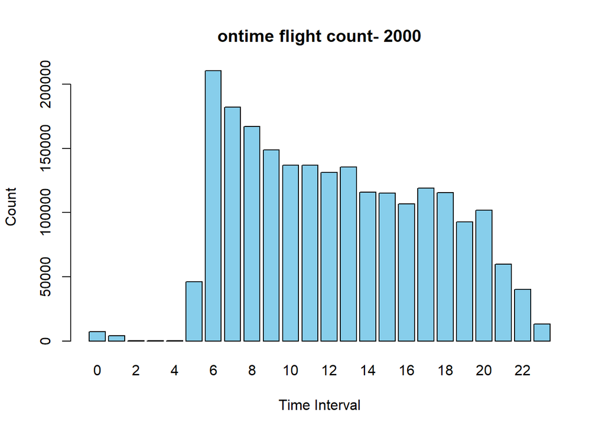

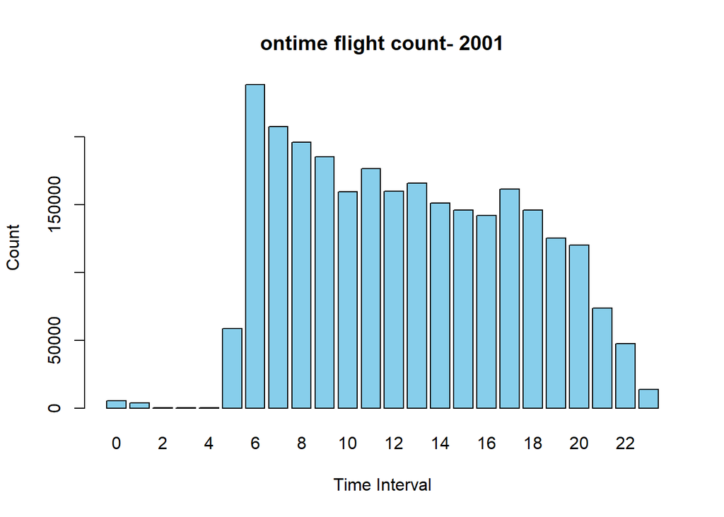

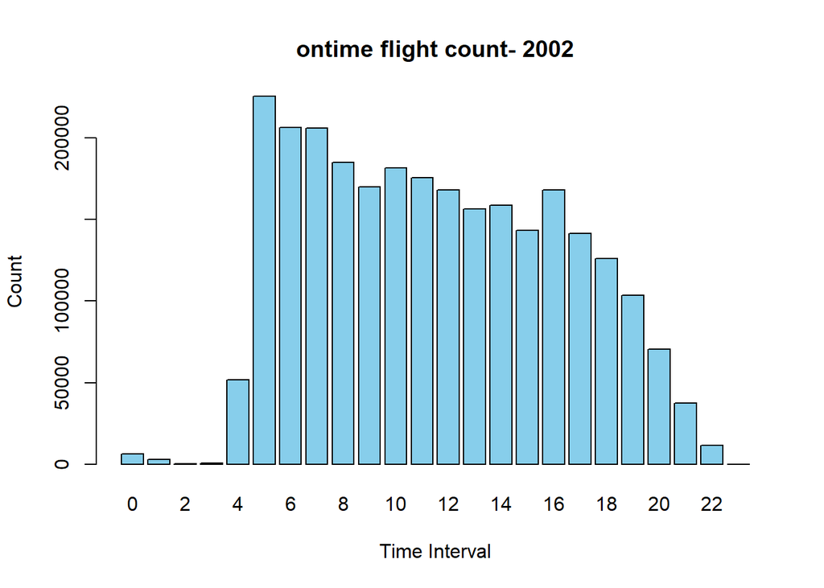

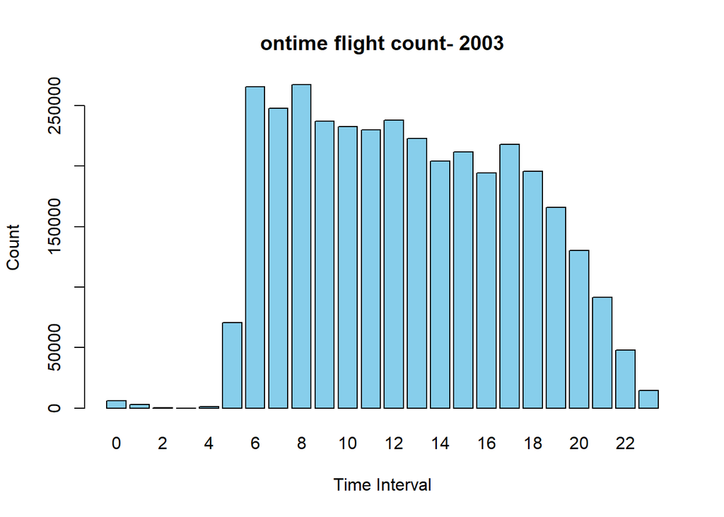

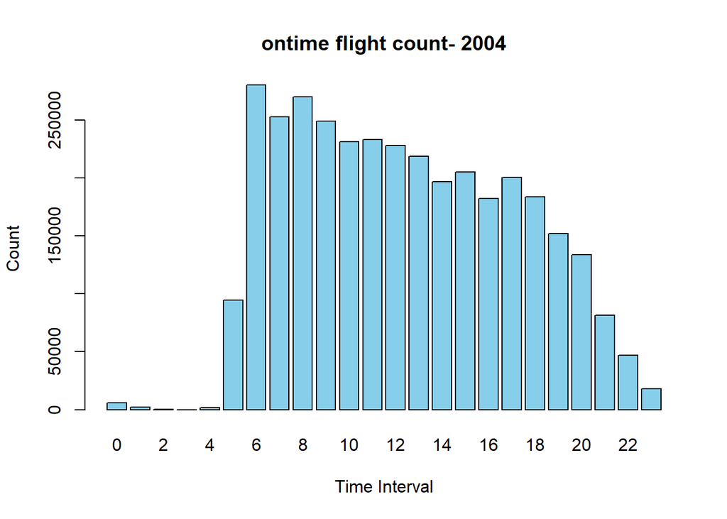

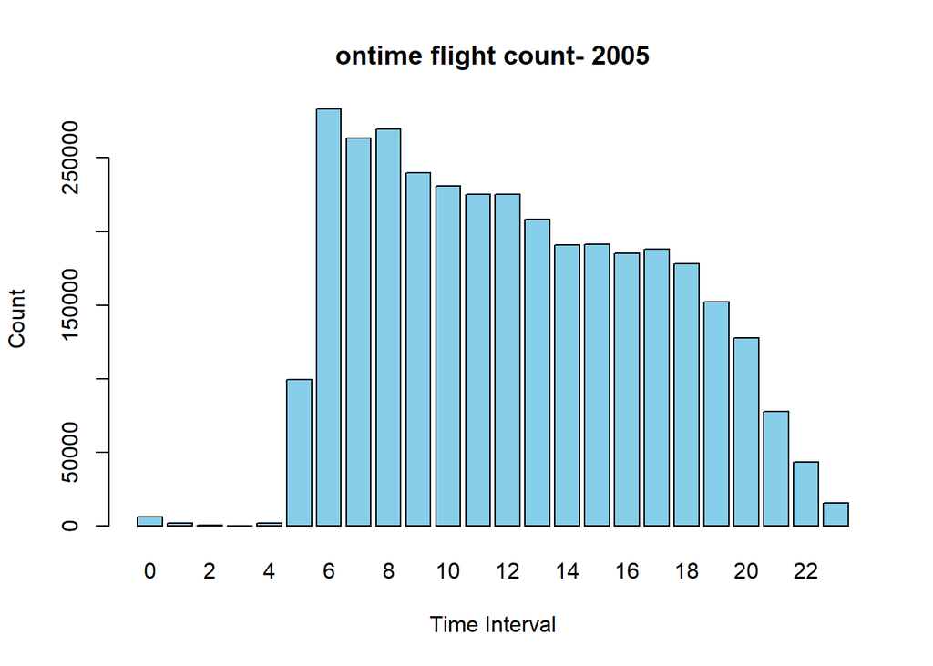

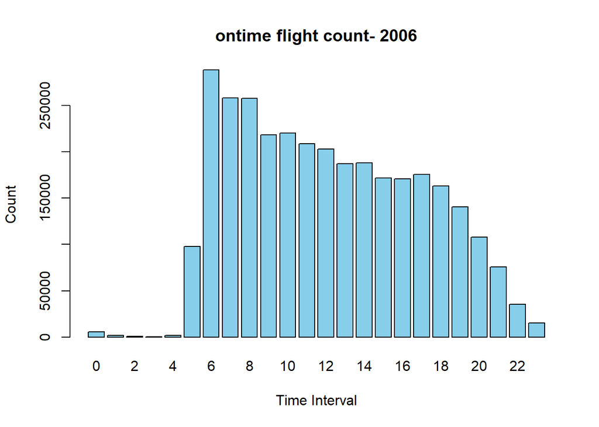

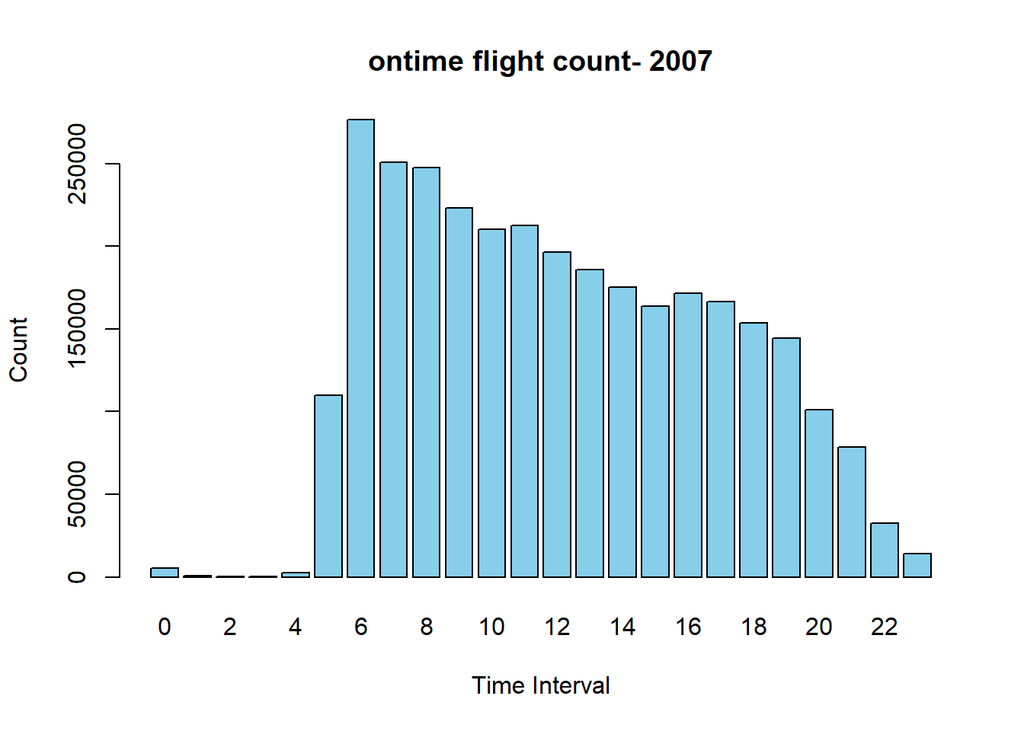

```r
#Predefine TimeIntervals
all_intervals <- data.frame(TimeInterval = c("[0,100]", "(100,200]", "(200,300]", "(300,400]", "(400,500]","(500,600]",
"(600,700]", "(700,800]", "(800,900]", "(900,1e+03]", "(1e+03,1.1e+03]", "(1.1e+03,1.2e+03]","(1.2e+03,1.3e+03]", "(1.3e+03,1.4e+03]", "(1.4e+03,1.5e+03]", "(1.5e+03,1.6e+03]", "(1.6e+03,1.7e+03]", "(1.7e+03,1.8e+03]", "(1.8e+03,1.9e+03]", "(1.9e+03,2e+03]", "(2e+03,2.1e+03]", "(2.1e+03,2.2e+03]", "(2.2e+03,2.3e+03]", "(2.3e+03,2.4e+03]"))

for(year in 1998:2007){
ontime_hour_df <- ontime_df %>%
  filter(Year == year) %>% #filter and keep only specific years
  mutate(TimeInterval = cut(DepTime, breaks = seq(0, 2400, by = 100), include.lowest = TRUE, include.highest = FALSE))     %>%
  group_by(TimeInterval) %>%
  summarise(count = n()) #count number of entries in each time interval

  ontime_hour_df <- merge(all_intervals, ontime_hour_df, by = "TimeInterval", all.x = TRUE, sort = FALSE)
  ontime_hour_df$count[is.na(ontime_hour_df$count)] <- 0 #if no entries in time interval put as 0



barplot(height = ontime_hour_df$count, names.arg = c("0","1", "2", "3", "4", "5", "6", "7", "8", "9", "10", "11", "12", "13", "14", "15", "16", "17", "18", "19", "20", "21", "22", "23"),
        xlab = "Time Interval",
        ylab = "Count",
        col = "skyblue",
        main = paste("ontime flight count-", year)
        )
}
```